# Slingshot: Lineage Inference for Single-cell Data

Kelly Street

2017-06-26

# 1 Introduction

The goal of `slingshot` is to use clusters of cells to uncover global structure and convert this structure into smooth lineages represented by one-dimensional variables, called “pseudotime.” We provide tools for learning cluster relationships in an unsupervised or semi-supervised manner and constructing smooth curves representing each lineage, along with visualization methods for each step.

## 1.1 Overview

The minimal input to `slingshot` is a matrix representing the cells in a reduced-dimensional space and a vector of cluster labels. If no cluster labels are provided, `slingshot` will treat the data as a single cluster and fit a standard principal curve. With these two inputs, the analysis then procedes:

- Find connections between clusters with the `getLineages` function, optionally specifying known start and end points.
- Construct smooth curves and pseudotime variables with the `getCurves` function.
- Assess the output of each step with built-in visualization tools.

Each of these steps is described in detail below. For now, we claim that using clusters of cells (rather than individual cells) to define global structure improves the stability of inferred lineages and smooth curves in place of piecewise-linear ones reduces variability in the inferred pseudotime variables.

## 1.2 Datasets

```r
library(splatter)
library(HSMMSingleCell)
data("HSMM_expr_matrix")
counts <- round(HSMM_expr_matrix)
params <- splatEstimate(counts)
params <- setParams(params, update = list(groupCells = 200, path.nonlinearProb = .5, de.prob = .6, de.facLoc = 1, de.facScale = 2, path.length=100))
sim <- splatSimulate(params, method = "paths")
dim(sim)
```

```
## Features  Samples
##    47192      200
```

The second dataset is provided with the `slingshot` and consists of a $140 \text{ cells} \times 2 \text{ dimensions}$ matrix of coordinates. This dataset will allow us to demonstrate some of the additional functionality offered by `slingshot`.

```r
data("slingshotExample")
rd2 <- rd; cl2 <- cl
dim(rd2) # data representing cells in a reduced dimensional space
```

```
## [1] 140   2
```

```r
length(cl2) # vector of cluster labels
```

```
## [1] 140
```

# 2 Upstream Analysis

## 2.1 Gene Filtering

To begin our analysis of the first simulated dataset, we need to reduce the dimensionality of our data and filtering out noisy genes is a typical first step. This will help improve the speed of downstream analyses, while keeping the loss of information to a minimum.

For the gene filtering step, we will retain any genes that are robustly expressed in at least some percentage of cells, making them potentially interesting cell-type marker genes. For the `splatter` dataset, we define a gene as being “robustly expressed” if it has a simulated count of 2.5 (roughly the median of all non-zero counts) or more and we set the minimum percentage of cells robustly expressing a gene to 10%.

```r
geneFilt <- apply(exprs(sim),1, function(gene){
  sum(gene >= 2.5) >= .1 * ncol(sim)
})
mean(geneFilt) # percentage of genes retained
```

```
## [1] 0.3035684
```

```r
sum(exprs(sim)[geneFilt,]) / sum(exprs(sim)) # percentage of reads retained
```

```
## [1] 0.7899422
```

```r
sim <- sim[geneFilt,]
```

## 2.2 Normalization

Since we are working with simulated data, we have the advantage of knowing what effects are present. In this case, we know that each simulated cell had a unique expected library size and we will apply quantile normalization in order to remove this effect.

```r
FQnorm <- function(counts){
  rk <- apply(counts,2,rank,ties.method='min')
  counts.sort <- apply(counts,2,sort)
  refdist <- apply(counts.sort,1,median)
  norm <- apply(rk,2,function(r){ refdist[r] })
  rownames(norm) <- rownames(counts)
  return(norm)
}
exprs(sim) <- FQnorm(exprs(sim))
```

## 2.3 Dimensionality Reduction

The fundamental assumption of `slingshot` is that cells which are transcriptionally similar will be close to each other in some reduced-dimensional space. Since we use Euclidean distances in constructing lineages and measuring pseudotime, it is important to have a low-dimensional representation of the data.

There are many methods available for this task and we will intentionally avoid the issue of determining which is the “best” method, as this likely depends on the type of data, method of collection, upstream computational choices, and many other factors. For the sake of time and simplicity, we will use principal components analysis (PCA).

When performing PCA, we do not scale the genes by their variance because we do not believe that all genes are equally informative. We want to find signal in the robustly expressed, highly variable genes, not dampen this signal by forcing equal variance across genes.

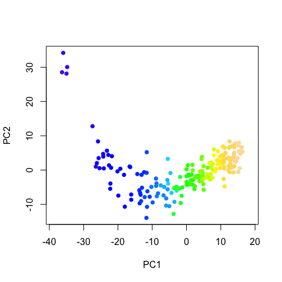

```r
pca <- prcomp(t(log1p(exprs(sim))), scale. = FALSE)
rd1 <- pca$x[,1:2]

plot(rd1, col = topo.colors(100)[sim$Step], pch=16, asp = 1)
```

## 2.4 Clustering Cells

The final input to `slingshot` is a vector of cluster labels for the cells. As we noted above, this is not strictly necessary for datasets in which researchers are confident that only a single lineage is present, but it is nonetheless highly recommended, since it allows for the potential discovery of novel branching events.

The clusters identified in this step will be used to determine the global structure of the underlying lineages (that is, their number, when they branch off from one another, and the approximate locations of those branching events). This is different than the typical goal of clustering single-cell data, which is to identify all biologically relevant cell types present in the dataset. For example, when determining global lineage structure, there is no need to distinguish between immature and mature neurons since both cell types will, presumably, fall along the same segment of a lineage.

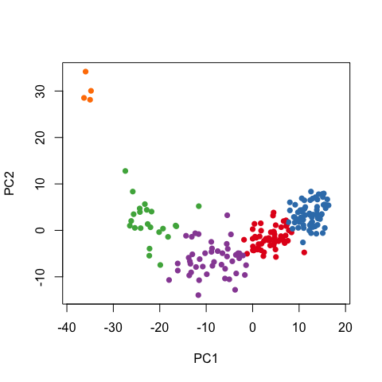

```r
cl1 <- kmeans(rd1, centers = 5)$cluster

plot(rd1, col = brewer.pal(9,"Set1")[cl1], pch=16, asp = 1)
```

# 3 Using Slingshot

These two steps can be run separately with the `getLineages` and `getCurves` functions, or together with the wrapper function, `slingshot`. We will run them separately for the sake of explanation, but note that any argument passed to either function would also be accepted by the `slingshot` function.

## 3.1 Identifying global lineage structure

The `getLineages` function takes as input an `n \times p` matrix and a vector of clustering results of length `n`. It maps connections between adjacent clusters using a minimum spanning tree (MST) and identifies paths through these connections that represent lineages.

This analysis can be performed in an entirely unsupervised manner or in a semi-supervised manner by specifying known beginning and end point clusters. For our simulated data, we get a single lineage and because we did not specify an initial cluster, one of the endpoints will be chosen arbitrarily as the beginning.

```r
lin1 <- getLineages(rd1, cl1)
```

```
## Using full covariance matrix
```

```r
lin1
```

```
## class: SlingshotDataSet
##
##  Samples Dimensions
##      200          2
##
## lineages: 1
## Lineage1: 5  3  4  1  2
##
## curves: 0
```

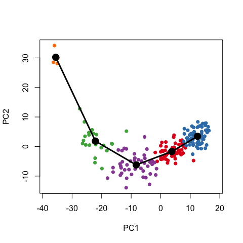

```r
plot(rd1, col = brewer.pal(9,"Set1")[cl1], asp = 1, pch = 16)
lines(lin1, lwd = 3)
```

We generally recommend the specification of a root cluster. This will have no effect on how the MST is constructed, but it will allow for nicer curves in datasets with a branching structure. When no initial cluster is specified and branching is present, `slingshot` will select an endpoint that maximizes the number of shared clusters (ie. the cluster at the end of the longest branch) as the beginning. For the second dataset, this means that the cluster on the left will be chosen as the origin.

```r
lin2 <- getLineages(rd2, cl2)
```

```
## Using full covariance matrix
```

```r
lin2
```

```
## class: SlingshotDataSet
##
##  Samples Dimensions
##      140          2
##
## lineages: 2
## Lineage1: 5  1  3  2
## Lineage2: 5  1  3  4
##
## curves: 0
```

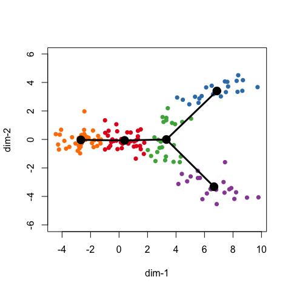

```r
plot(rd2, col = brewer.pal(9,"Set1")[cl2], asp = 1, pch = 16)
lines(lin2, lwd = 3)
```

At this step, `slingshot` also allows for the specification of known endpoints. Clusters which are specified as terminal cell states will be constrained to have only one connection when the MST is constructed (ie., they must be leaf nodes). This constraint could potentially impact how other parts of the tree are drawn, as shown in the next example where we specified the middle cluster in the branch as an endpoint.

```r
lin3 <- getLineages(rd2, cl2, end.clus = '3')
```

```
## Using full covariance matrix
```

```r
lin3
```

```
## class: SlingshotDataSet
##
##  Samples Dimensions
##      140          2
##
## lineages: 3
## Lineage1: 5  1  3
## Lineage2: 5  1  2
## Lineage3: 5  1  4
##
## curves: 0
```

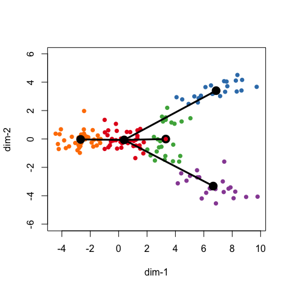

```r
plot(rd2, col = brewer.pal(9,"Set1")[cl2], asp = 1, pch = 16)
lines(lin3, lwd = 3, show.constraints = TRUE)
```

There are a few additional arguments we could have passed to `getLineages` for more greater control:

- `dist.fun` is a function for computing distances between clusters. The default is squared distance between cluster centers normalized by their joint covariance matrix.
- `omega` is a granularity parameter, allowing the user to set an upper limit on connection distances. This can be useful for identifying outlier clusters which are not a part of any lineage.

After constructing the MST, `getLineages` identifies paths through the tree to designate as lineages. At this stage, a lineage will consist of an ordered set of cluster names, starting with the root cluster and ending with a leaf. The output of `getLineages` is a `slingshotDataSet` which holds all of the inputs as well as a list of lineages and some additional information on how they were constructed.

## 3.2 Constructing smooth curves and ordering cells

In order to model development along these various lineages, we will construct smooth curves with the function `getCurves`. Using smooth curves based on all the cells eliminates the problem of cells projecting onto vertices of piece-wise linear trajectories and makes `slingshot` more robust to noise in the clustering results.

When there are two or more lineages, we add an additional step to the algorithm: averaging curves near shared cells. Both lineages should agree fairly well on cells that have yet to differentiate, so at each iteration we average the curves in the neighborhood of these cells. This increases the stability of the algorithm and produces smooth branching lineages.

```r
crv1 <- getCurves(lin1)
crv1
```

```
## class: SlingshotDataSet
##
##  Samples Dimensions
##      200          2
##
## lineages: 1
## Lineage1: 5  3  4  1  2
##
## curves: 1
## Curve1: Length: 80.603   Samples: 200
```

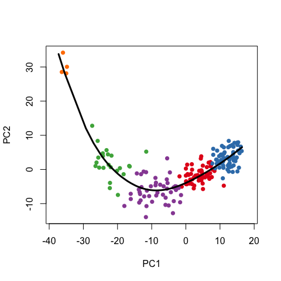

```r
plot(rd1, col = brewer.pal(9,"Set1")[cl1], asp = 1, pch = 16)
lines(crv1, lwd = 3)
```

The output of `getCurves` is an updated `slingshotDataSet` which now contains the simultaneous principal curves and additional information on how they were fit. The simultaneous principal curves can be accessed using the `curves` function, which will return a list of `principal.curve` objects. These objects consist of the following slots:

- `s`: the matrix of points that make up the curve. These correspond to the orthogonal projections of the data points.
- `tag`: indices which can be used to put the cells along a curve in order based their projections.
- `lambda`: arclengths along the curve from the beginning to each cell’s projection.
- `dist`: the squared distances between data points and their projections onto the curve.
- `w`: the vector of weights along this lineage. Cells that were unambiguously assigned to this lineage will have a weight of `1`, while cells assigned to other lineages will have a weight of `0`. It is possible for cells to have weights of `1` (or very close to 1) for multiple lineages, if they are positioned before a branching event.

# 4 Downstream Analysis

## 4.1 Identifying temporally expressed genes

```r
require(gam)
t <- pseudotime(crv1)
y <- exprs(sim)
gam.pval <- apply(y,1,function(z){
  d <- data.frame(z=z, t=t)
  tmp <- gam(z ~ lo(t), data=d)
  p <- summary(tmp)[4][[1]][1,5]
  p
})
```

We can then pick out the top genes for each lineage and visualize their expression over developmental time with a heatmap.

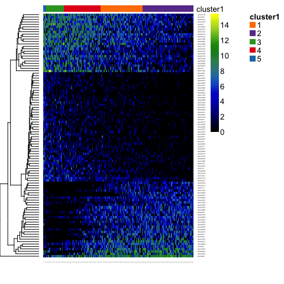

```r
require(clusterExperiment)
topgenes1 <- names(sort(gam.pval, decreasing = FALSE))[1:100]
heatdata1 <- exprs(sim)[rownames(exprs(sim)) %in% topgenes1, order(t, na.last = NA)]
heatclus1 <- cl1[order(t, na.last = NA)]
ce1 <- clusterExperiment(heatdata1, heatclus1, transformation=identity)
plotHeatmap(ce1, clusterSamplesData="orderSamplesValue")
```

# 6 References